# データ解析論II第11講

後藤 晶

# 講義資料

## 今日の資料はコチラから．

[figure not shown]

スマホで見る方は**QRコード**を読み込んでください

- 【第1講】イントロダクション
- 【第2講】前期の復習（一般線形モデル）
- 【第3講】一般化線形モデル①
- 【第4講】一般化線形モデル②，一般線形混合モデル
- 【第5講】一般化線形混合モデル- 因子分析①
- 【第6講】因子分析① 因子分析②
- 【第7講】因子分析②
- 【第8講】パス解析
- 【第9講】構造方程式モデリング
- 【第10講】機械学習①：分類
- 【第11講】機械学習②：サポートベクターマシンによる分類**テキストマイニング**
- 【第12講】マッチング法・回帰不連続デザイン
- 【第13講】操作変数法・差の差の分析
- 【第14講】演習・振り返り

### radiantの起動

```r
# library(radiant)
# radiant()
```

## 前回の復習

### 分類について

**[テキスト](https://www.dropbox.com/s/v4qbzruq7sgbazs/text.pdf?dl=0)**

- パスワード：i___c__2_1_da
  - 詳細は授業時に説明します．
- p286「第12章 似た者同士にグループ分けしたい–クラスター分析」

### 分類とは

- あるデータから対象を区別すること
  - ex.出身地域（質的変数）から人を区別することは可能だが，身長・体重など（量的変数）から区別することは難しい．

### 階層クラスタリングと非階層クラスタリング

- 階層クラスタリング：段階的に分割or結合を繰り返しながらクラスターを形成する．
- 非階層クラスタリング：一斉に対象を分割してクラスターを形成する．

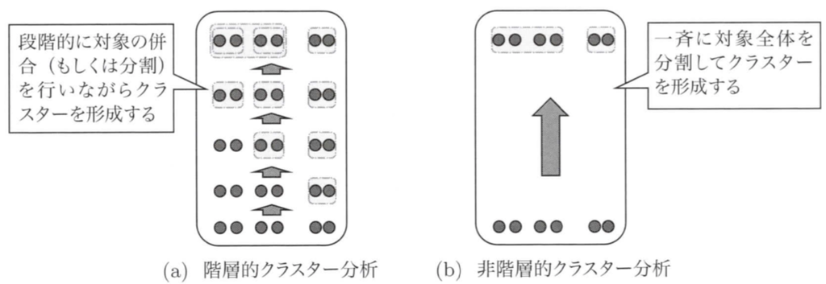

### 階層クラスタリングと非階層クラスタリングの手順

- 階層クラスタリング：段階的に分割or結合を繰り返しながらクラスターを形成する．
1. 非類似度行列の算出
2. デンドログラムの作成
3. クラスター数の決定
4. クラスター数の妥当性の確認
5. クラスターの特徴の考察
- 非階層クラスタリング：一斉に対象を分割してクラスターを形成する．
1. クラスター数の決定
2. クラスター数の決定
3. クラスター数の妥当性の確認
4. クラスターの特徴の考察

### クラスター分析をやってみよう

**[データ](https://akrgt.github.io/2019DA/data/yasai.csv)**

- データの読み込み：日本語が混ざっているので，RStudioに読みこませる→“from global workspace”から読み込み
  - RStudioに読み込ませるときには画像の通りのプロセスを行う

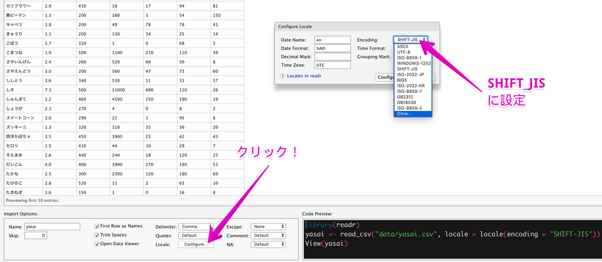

```r
library(readr)
yasai <- read_csv("~/Dropbox/Education/2019Meiji/[3_Wed2]Data_Analytics/analysis/data/yasai.csv",
    locale = locale(encoding = "SHIFT-JIS"))
```

#### データ分析の目的

- 6つの野菜の要素に基づいて，栄養素が似た者同士をグループ化する．
  - クラスター：同じ種類の人やモノの集合のこと
- 非類似度行列の作成

```r
DO <- dist(yasai, method="euclidean")
D <- (1/2)*DO^2
```

- デンドログラム作成の下処理

```r
ysi.out<-hclust(d=D,method="ward.D")
```

- デンドログラム作成

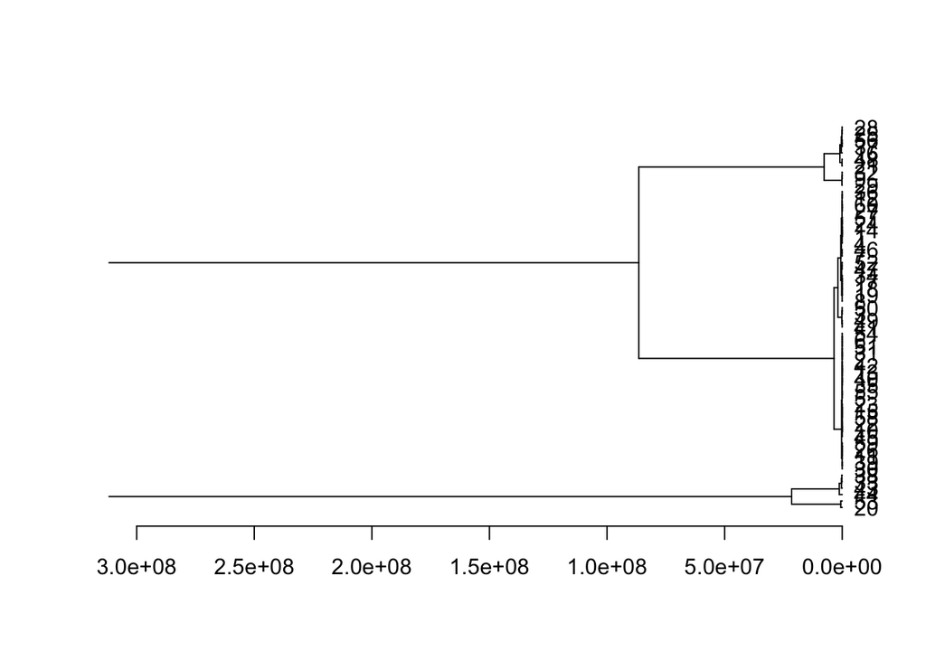

```r
plot(as.dendrogram(ysi.out), xlim = c(300000000,0), horiz=T)
```

- だいたい似た者同士がグループになっている．
- 細かく項目について評価してみましょう．

### 解釈のためのクラスター数の決定と妥当性の評価：

### K-meansクラスタリング

- 2つの真のクラスターを持つシミュレーションデータ例
  - 最初の25個の観測値と，次の25個の観測値の分布全体を平行移動して離す．

```r
set.seed(2)
x <- matrix(rnorm(50*2), ncol=2)
x[1:25,1]=x[1:25,1]+3
x[1:25,2]=x[1:25,2]-4
```

- K=2と設定してK-means法を実行

```r
km.out <-kmeans(x, 2, nstart = 20)
km.out
```

```
## K-means clustering with 2 clusters of sizes 25, 25
##
## Cluster means:
##         [,1]       [,2]
## 1  3.3339737 -4.0761910
## 2 -0.1956978 -0.1848774
##
## Clustering vector:
##  [1] 1 1 1 1 1 1 1 1 1 1 1 1 1 1 1 1 1 1 1 1 1 1 1 1 1 2 2 2 2 2 2 2 2 2 2
## [36] 2 2 2 2 2 2 2 2 2 2 2 2 2 2 2
##
## Within cluster sum of squares by cluster:
## [1] 63.20595 65.40068
##  (between_SS / total_SS =  72.8 %)
##
## Available components:
##
## [1] "cluster"      "centers"      "totss"        "withinss"
## [5] "tot.withinss" "betweenss"    "size"         "iter"
## [9] "ifault"
```

- 結果のプロット

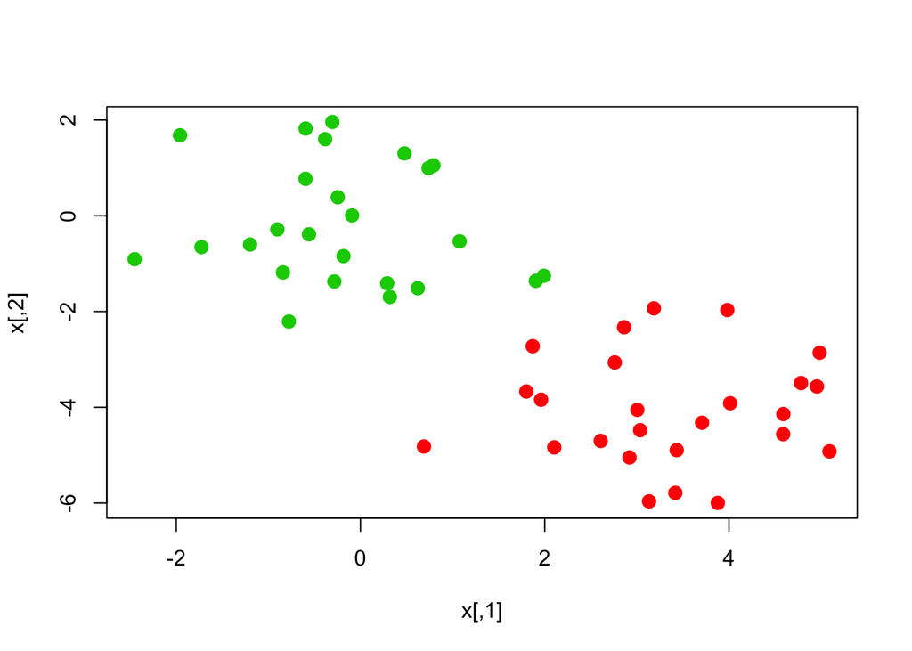

```r
plot(x, col=(km.out$cluster+1),  pch=20, cex=2)
```

- これで2群に分けられることを確認できた．
- 3群以上ある場合は因子分析or主成分分析で第1主成分および第2主成分を取り出して分析してもよい．

```r
set.seed(4)

km.out <-kmeans(x, 3, nstart = 20)
km.out
```

```
## K-means clustering with 3 clusters of sizes 17, 23, 10
##
## Cluster means:
##         [,1]        [,2]
## 1  3.7789567 -4.56200798
## 2 -0.3820397 -0.08740753
## 3  2.3001545 -2.69622023
##
## Clustering vector:
##  [1] 1 3 1 3 1 1 1 3 1 3 1 3 1 3 1 3 1 1 1 1 1 3 1 1 1 2 2 2 2 2 2 2 2 2 2
## [36] 2 2 2 2 2 2 2 2 3 2 3 2 2 2 2
##
## Within cluster sum of squares by cluster:
## [1] 25.74089 52.67700 19.56137
##  (between_SS / total_SS =  79.3 %)
##
## Available components:
##
## [1] "cluster"      "centers"      "totss"        "withinss"
## [5] "tot.withinss" "betweenss"    "size"         "iter"
## [9] "ifault"
```

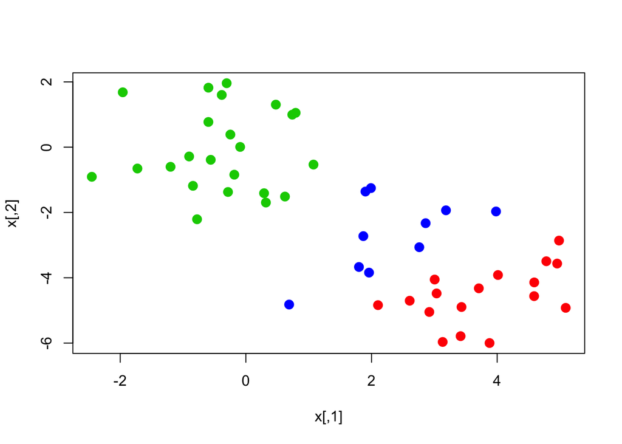

```r
plot(x, col=(km.out$cluster+1),  pch=20, cex=2)
```

## 今日やること

### テキストマイニングを行う

- 小説的な文章の分析
- twitterデータの分析

#### txtから文章を読み込む

**[ファイル](https://akrgt.github.io/2019DA/data/wagahaiwa_nekodearu.txt)** * 『吾輩は猫である（夏目漱石著）』[青空文庫](https://www.aozora.gr.jp/cards/000148/files/789_14547.html)にて公開されているものを一部使用

```r
library(RMeCab)
library(readr)
RMecabFreq.result<-RMeCabFreq(file = "/Users/akira/Dropbox/Education/2019Meiji/[3_Wed2]Data_Analytics/analysis/data/wagahaiwa_nekodearu.txt")
```

```
## file = /Users/akira/Dropbox/Education/2019Meiji/[3_Wed2]Data_Analytics/analysis/data/wagahaiwa_nekodearu.txt
## length = 1644
```

- `RMeCab`パッケージが必要であるため，インストールすること

```r
head(RMecabFreq.result)
```

```
##       Term    Info1 Info2 Freq
## 1       あ フィラー     *    4
## 2     あー フィラー     *    1
## 3       え フィラー     *   11
## 4   なんか フィラー     *    1
## 5   あえて     副詞  一般    1
## 6 あたかも     副詞  一般    3
```

```r
  # データを表示
RMecabFreq.result.2<-RMecabFreq.result[order(RMecabFreq.result$Freq, decreasing = T),]
  # 頻度が多い順に並べ替える
head(RMecabFreq.result.2)
```

```
##      Term  Info1    Info2 Freq
## 1626   。   記号     句点  329
## 234    の   助詞   連体化  295
## 193    て   助詞 接続助詞  288
## 168    は   助詞   係助詞  268
## 223    を   助詞   格助詞  247
## 147    た 助動詞        *  215
```

```r
  # データを表示
sum(RMecabFreq.result.2[,4])
```

```
## [1] 7447
```

```r
  # 全頻度の合計
sum(RMecabFreq.result.2$Freq)
```

```
## [1] 7447
```

```r
  # 全頻度の合計
```

```r
nrow(RMecabFreq.result.2) / sum(RMecabFreq.result.2$Freq)
```

```
## [1] 0.22076
```

```r
write.table(RMecabFreq.result.2, file = "wordlist.csv", sep = ",", row.names = T, col.names = NA, fileEncoding = "SHIFT_JIS")
```

```r
collocate.result<-collocate(file = "/Users/akira/Dropbox/Education/2019Meiji/[3_Wed2]Data_Analytics/analysis/data/wagahaiwa_nekodearu.txt", node="吾輩", span=5)
```

```
## file = /Users/akira/Dropbox/Education/2019Meiji/[3_Wed2]Data_Analytics/analysis/data/wagahaiwa_nekodearu.txt
## length = 1534
```

```r
head(collocate.result)
```

```
##       Term Before After Span Total
## 1       、     10     1   11   123
## 2       。     53     4   57   329
## 3       「      2     2    4    42
## 4 あたかも      1     0    1     3
## 5     あと      1     0    1     4
## 6     ある     17     4   21    89
```

### twitterデータの感情分析

```r
library(rtweet)
library(devtools)
library(pipeR)
library(wordcloud2)
library(RMeCab)
library(dplyr)
```

- それぞれのパッケージが必要となるので，インストールすること．

```r
keyword <- search_tweets("情コミ",n=20000,include_rts = FALSE,langs = "ja")
  # キーワードで検索（第一引数：検索したいキーワード、第二引数:取得件数、第三引数:リツイートを取得するか、第四引数：どの言語のツイートを取得するか



write.csv(keyword$text,file = "tweets.csv",sep = ",",col.names = T,row.names = F, fileEncoding = "UTF-8")
  #ファイルに書き込み
```

### Stop Wordの設定

- 余計な言葉が入っていることもある．
  - ex. 「と思う」とか
- そんなのは“stopwords.csv” というファイルを作って，除外処理をしよう
  - すでに代表的なストップワードは別途資料に入れてある．，．

**[除外単語](https://akrgt.github.io/2019DA/data/stopwords.txt)**

```r
# 自作関数 --------------------------------------------------------------------

#ストップワードの除外
stopwords <- function(df){

  data <- df
  #ストップワードファイルを読み込む
  stop_words <- read.csv("/Users/akira/Dropbox/Education/2019Meiji/[3_Wed2]Data_Analytics/analysis/data/stopwords.txt")

  #ストップワードを除外する
  for (i in 1:nrow(rc)) {
    data <- data[data[,1] != stop_words[i,],]
  }

  return(data)

}
```

```r
tweetword <- RMeCabFreq("tweets.csv")
```

```
## file = tweets.csv
## length = 583
```

```r
  #頻出ワードを抽出

tweetword <- tweetword[tweetword[, 2] == "名詞"&( tweetword[, 3] == "一般" | tweetword[, 3] == "固有名詞" ),]
  #名詞、一般、固有名詞に絞る


tweetword <- tweetword[ tweetword[,4] > 10, ]
  #頻出度合いが10以上のキーワードのみを抽出


#tweetword <- stopwords(tweetword)
  #ストップワードを除外


tweetword <-  tweetword %>%
  arrange(desc(Freq))
  #Freq(頻度)の降順でソート
```

### ワードクラウドによる可視化

```r
tweetword <- tweetword[,c("Term","Freq")]
  #データを読み込む

wordcloud2(tweetword)
```

[interactive chart not shown]

```r
  #ワードクラウドで可視化
```

### 感情分析：吾輩は猫である編

- 感情分析：テキストにおけるポジティブな単語やネガティブな単語を数えたり，「喜び」や「怒 り」のような感情を表す単語を数えたりする分析手法．
- [こちら](https://qiita.com/rmecab/items/b1a55a0e3a0a8637a461) も参考になりそう．

#### 単語感情極性表(Semantic Orientations of Words)の読み込み

- [開発者サイト](http://www.lr.pi.titech.ac.jp/~takamura/pndic_ja.html)
- -1に近いほどネガティブ，+1に近いほどポジティブであると評価する．

```r
sow <- read.table("http://www.lr.pi.titech.ac.jp/~takamura/pubs/pn_ja.dic",sep=":",
                  col.names=c("term","kana","pos","value"),
                  colClasses=c("character","character","factor","numeric"),
                  fileEncoding="Shift_JIS")
```

- 様々な辞書があるが，ここではこれを使いましょう．

#### 『吾輩は猫である』でやってみる．

```r
waganeko <- RMeCabFreq("wordlist.csv")
```

```
## file = wordlist.csv
## length = 3020
```

```r
  #頻出ワードを抽出

waganeko2 <- subset(waganeko,Term %in% sow$term)
  #単語感情極性表に含まれるものを抽出


waganeko2 <- merge(waganeko2,sow,by.x = c("Term","Info1"),by.y = c("term","pos"))
  #単語感情極性表の属性をマージ

waganeko2 <- waganeko2[4:(ncol(waganeko2)-2)]*waganeko2$value
  #頻度(Freq) × 表の値(Value)でスコアを算出
```

#### 可視化

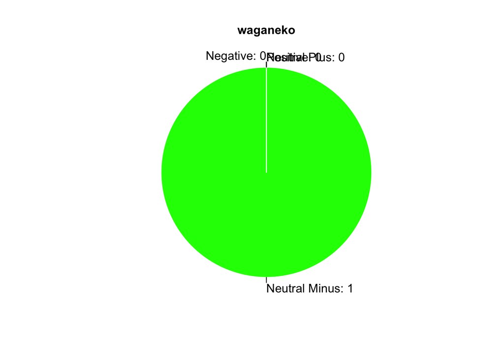

```r
waganeko2 <-c(sum(waganeko2 > 0.5 & waganeko2 < 1.0),
               sum(waganeko2 > 0 & waganeko2 < 0.5),
               sum(waganeko2 < 0 & waganeko2 < -0.5),
               sum(waganeko2 < -0.5 & waganeko2 < -1)) %>%
  as.data.frame()

  #描画用データを作成
  #0.5～1.0　ポジティブ/0～0.5 ややポジティブ/0～-0.5 ややネガティブ/-0.5～-1 ネガティブ

#パイチャートで描画
dv=c(waganeko2[1:4,])

pie(dv,radius=1,labels=c(paste("Positive:",dv[1]),
                         paste("Neutral Plus:",dv[2]),
                         paste("Neutral Minus:",dv[3]),
                         paste("Negative:",dv[4])),col=c("#ff0000","#ffff00","#00ff00","#0000ff"),
                        clockwise=T,border="#ffffff",main="waganeko",cex.main=1, )
```

### 感情分析：tweet編

```r
tweetword <- RMeCabFreq("tweets.csv")
```

```
## file = tweets.csv
## length = 583
```

```r
  #頻出ワードを抽出

tweetword2 <- subset(tweetword,Term %in% sow$term)
  #単語感情極性表に含まれるものを抽出

tweetword2 <- merge(tweetword2,sow,by.x = c("Term","Info1"),by.y = c("term","pos"))
  #単語感情極性表の属性をマージ

tweetword2 <- tweetword2[4:(ncol(tweetword2)-2)]*tweetword2$value
  #頻度(Freq) × 表の値(Value)でスコアを算出
```

#### 可視化

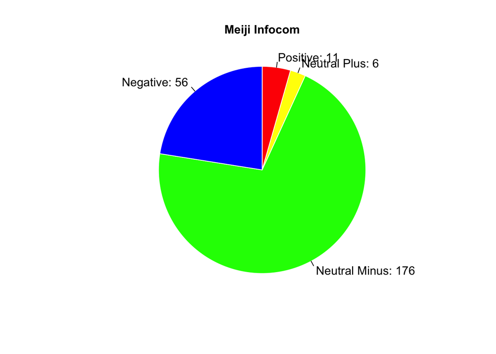

```r
tweetword2 <-c(sum(tweetword2 > 0.5 & tweetword2 < 1.0),
               sum(tweetword2 > 0 & tweetword2 < 0.5),
               sum(tweetword2 < 0 & tweetword2 < -0.5),
               sum(tweetword2 < -0.5 & tweetword2 < -1)) %>%
  as.data.frame()

  #描画用データを作成
  #0.5～1.0　ポジティブ/0～0.5 ややポジティブ/0～-0.5 ややネガティブ/-0.5～-1 ネガティブ


dv=c(tweetword2[1:4,])
pie(dv,radius=1,labels=c(paste("Positive:",dv[1]),
                         paste("Neutral Plus:",dv[2]),
                         paste("Neutral Minus:",dv[3]),
                         paste("Negative:",dv[4])),col=c("#ff0000","#ffff00","#00ff00","#0000ff"),
                        clockwise=T,border="#ffffff",main="Meiji Infocom",cex.main=1)
```

```r
  #パイチャートで描画
```

# 資料

## Rでデータを扱う時に注意すべきこと

- 必ず数字／文字は半角で入力する．
- 日本語は使わずにローマ字を使用する．
- コメントアウト（コードではなく，関係ないメモを入れること）をするときは半角の「#」から始める．
- メモする内容は全角でもよい．
- ファイル名およびパスには決して全角の文字（ひらがな，カタカナ，漢字，全角スペースなど）を入れてはいけない．
- 半角英数字だけにする．
- 慌てずに落ち着いて操作すれば，決して難しくない．
- 1つずつ落ち着いて作業することを心がける．
- 「わからない」ことを恐れない
- 周りの友人に聞いたり，教員に確認したりしよう．

### リアクションペーパー：

- 授業で学んだことおよび感想を下記リンクからお答えください． [リアクションペーパー](https://forms.gle/DqVa7ea9py9biejJ7)

## 参考文献など

### 参考図書（和書）

*統計について*

- [山田剛史, 杉澤武俊, 村井潤一郎, 2008, 『Rによる優しい統計学』, オーム社, *明治e-libへ*](https://elib.maruzen.co.jp/elib/html/BookDetail/Id/3000002659?7)
- 基本的な考え方を紹介してくれる本．oh-o!Meijiにログインすれば無料で読める．
- [内田治, 西澤英子 2008, 『Rによる統計的検定と推定』, オーム社, *明治e-libへ*](https://elib.maruzen.co.jp/elib/html/BookDetail/Id/3000002728?9)
- 基本的な考え方を紹介してくれる本．oh-o!Meijiにログインすれば無料で読める．
- [奥村晴彦 2008, 『Rによる統計的検定と推定』, オーム社, *明治e-libへ*](https://elib.maruzen.co.jp/elib/html/BookDetail/Id/3000002728?9)
- 基本的な考え方を紹介してくれる本．oh-o!Meijiにログインすれば無料で読める．
- [小杉考司, 2019, 『言葉と数式で理解する多変量解析入門』, 北大路出版](https://www.amazon.co.jp/dp/476283047X)
- 非常に平易な言葉で多変量解析について説明がなされている．ただし，一歩戻って基本的RStudioの使い方と基本的な統計(t検定や回帰分析，カイ2乗検定など)を学ぶのであれば，[小杉考司, 2019, 『Rでらくらく心理統計 RStudio徹底活用』](https://www.amazon.co.jp/dp/4065144876)などもよいでしょう．
- [星野匡郎, 田中久稔, 2018, 『Rによる実証分析 ―回帰分析から因果分析へ―』, 裳華房](https://www.amazon.co.jp/dp/427421947X)
- Rを用いた様々な分析手法について記載されている．春学期の内容も含まれるが，主に秋学期の内容をカバーしている．
- [川端一光, 岩間徳兼, 鈴木雅之, 2018, 『Rによる多変量解析入門 - データ解析の実践と理論』, オーム社](https://www.amazon.co.jp/dp/4274222365/)
- 基本的な技術を学ぶことができる．かなり良書．
- *この講義の作成にかなり使っています．*
  - [森田果, 2014, 『実証分析入門 - データから「因果関係」を読み解く作法』, 日本評論社](https://www.amazon.co.jp/dp/4535557934)
- 法律系の先生が書かれた本だが，なかなかわかりやすく面白い．どちらかというと秋学期の内容に関わる．
- [地道正行, 2018, 『データサイエンスの基礎 Rによる統計学独習』, 裳華房](https://www.amazon.co.jp/dp/4785315784)
- 細かく書かれているが，数式も多い．講義内で数学的説明の時間を十分に確保できないため，興味のある方はこちらへ．

*再現性の議論について*

- [高橋康介, 2018, 『再現可能性のすゝめ (Wonderful R 3)』, 共立出版](https://www.amazon.co.jp/dp/4320112431)
- [江口哲史(編), 2018『自然科学研究のためのR入門―再現可能なレポート執筆実践― (Wonderful R 4)』, 共立出版](https://www.amazon.co.jp/dp/432011244X)
- いずれの本も再現可能性のためにRStudioとRMarkdownの使い方について紹介した本．

*分析の一連の流れについて*

- [岩波データサイエンス](https://elib.maruzen.co.jp/elib/html/SeriesDetail/Id/3000047689?28)
- 様々な応用的な統計の考え方を紹介している．
- [松村優哉, 湯谷啓明, 紀ノ定保礼, 前田和寛, 2018, 『RユーザのためのRStudio[実践]入門−tidyverseによるモダンな分析フローの世界』, 技術評論社](https://www.amazon.co.jp/dp/4774198536/)
- RStudioを用いたデータ収集，データ整形，可視化，レポーティングといった一連の分析の流れに関する本．

### 参考図書（洋書）

*計量経済について* * [Heiss, Florian, 2016, “Using R for Introductory Econometrics”, Amazon Digital Services](https://www.amazon.co.jp/dp/1523285133/) - 洋書．Rを用いた計量経済学入門の教科書だが，手を動かしながら学んでいくことができる．

### 参考web資料

*Rによる統計* * [Rjpwiki](http://www.okadajp.org/RWiki/) - Rに関する基礎知識の共有などが図られている．

- r-wakalang
- Slackのグループ．全く知らない人たちが色々質問に答えてくれたりも．
- [からだにいいもの](https://www.karada-good.net)
- Rに関する様々な情報が掲載されている．多少応用的なトピックが多い．
- [marketechlabo](https://www.marketechlabo.com/r-best-packages/)
- ちょっと新しいパッケージ等が紹介されていて興味深い

*RMarkdownの使い方*

- [R Markdown入門](https://kazutan.github.io/kazutanR/Rmd_intro.html)
- Rマークダウンに限らずデータ操作や可視化などの技術についても[他ページ](https://kazutan.github.io/kazutanR/index.html)で紹介している．
- [R Markdownで楽々レポートづくり](http://gihyo.jp/admin/serial/01/r-markdown/0001)
- 全8話のRMarkdownの操作方法について．この記事の内容は[高橋康介, 2014, 『ドキュメント・プレゼンテーション生成 (シリーズ Useful R 9)』, 共立出版](https://www.amazon.co.jp/dp/4320123727)をもとに作成されている．しかし，この記事を読めばよく分かる．．．

## データの概要

### データの頭10個

```r
library(DT)
library(readr)
exdataset <- read_csv("/Users/akira/Dropbox/Education/2019MEIJI/[3_Wed2]Data_Analytics/analysis/data/exdataset.csv")
DT::datatable(exdataset)
```

|  | SUB_HAP | SUB_SAT | SUB_SLP | DIC_PAR | DIC_FRI | DIC_OTH | ULT_PRO_PAR | ULT_PRO_FRI | ULT_PRO_OTH | ULT_REC_PAR | ULT_REC_FRI | ULT_REC_OTH | TRU_PAR | TRU_FRI | TRU_OTH | SPN_UNM | SPN_THK | SPN_FEA | SPN_LIV | SPN_IMP | KAN_SEC | KAN_THI | KAN_SUP | KAN_PRD | KAN_KYK | DED_SHI | DED_TEN | DED_JIG | DED_KIS | … |
| --- | --- | --- | --- | --- | --- | --- | --- | --- | --- | --- | --- | --- | --- | --- | --- | --- | --- | --- | --- | --- | --- | --- | --- | --- | --- | --- | --- | --- | --- | --- |
| 1 | 4 | 4 | 9 | 10 | 5 | 3 | 10 | 5 | 5 | 0 | 1 | 1 | 10 | 5 | 3 | 1 | 3 | 3 | 3 | 4 | 1 | 2 | 1 | 2 | 3 | 1 | 1 | 1 | 3 | … |
| 2 | 6 | 5 | 8 | 3 | 1 | 0 | 3 | 5 | 7 | 3 | 5 | 5 | 2 | 1 | 0 | 2 | 3 | 3 | 2 | 3 | 3 | 3 | 2 | 2 | 3 | 2 | 2 | 2 | 3 | … |
| 3 | 5 | 3 | 3 | 10 | 5 | 0 | 10 | 5 | 0 | 10 | 5 | 0 | 10 | 5 | 0 | 2 | 3 | 3 | 2 | 3 | 3 | 3 | 3 | 2 | 2 | 3 | 2 | 2 | 3 | … |
| 4 | 5 | 5 | 4 | 2 | 0 | 0 | 5 | 5 | 5 | 5 | 5 | 5 | 2 | 2 | 2 | 4 | 3 | 3 | 3 | 3 | 2 | 2 | 4 | 4 | 3 | 2 | 2 | 2 | 3 | … |
| 5 | 3 | 3 | 2 | 0 | 0 | 0 | 5 | 5 | 0 | 5 | 5 | 0 | 10 | 10 | 1 | 1 | 2 | 3 | 3 | 3 | 1 | 1 | 1 | 1 | 3 | 4 | 4 | 4 | 2 | … |
| 6 | 7 | 7 | 6 | 3 | 1 | 0 | 3 | 1 | 0 | 3 | 1 | 0 | 5 | 3 | 0 | 3 | 3 | 3 | 3 | 3 | 3 | 3 | 2 | 3 | 3 | 3 | 3 | 3 | 3 | … |
| 7 | 5 | 5 | 6 | 5 | 2 | 0 | 5 | 3 | 2 | 0 | 1 | 1 | 10 | 5 | 0 | 2 | 2 | 2 | 2 | 3 | 3 | 3 | 1 | 3 | 4 | 4 | 2 | 4 | 2 | … |
| 8 | 5 | 5 | 8 | 5 | 5 | 0 | 5 | 5 | 0 | 5 | 5 | 0 | 5 | 8 | 0 | 4 | 4 | 4 | 4 | 3 | 4 | 4 | 4 | 3 | 3 | 3 | 3 | 3 | 3 | … |
| 9 | 1 | 3 | 1 | 10 | 5 | 0 | 10 | 5 | 0 | 10 | 5 | 0 | 10 | 8 | 4 | 3 | 4 | 4 | 4 | 4 | 3 | 1 | 1 | 1 | 3 | 3 | 3 | 3 | 4 | … |
| 10 | 7 | 7 | 5 | 5 | 5 | 0 | 5 | 5 | 5 | 5 | 5 | 0 | 3 | 3 | 0 | 2 | 3 | 3 | 3 | 3 | 2 | 2 | 2 | 2 | 3 | 2 | 2 | 2 | 3 | … |

[output cut: 953 more lines]

### 変数名リスト

#### 主観的指標

| 項目名 | データタイトル | 質問項目 | 回答 |
| --- | --- | --- | --- |
| 主観的幸福度 | SUB_HAP | 現在，あなたはどの程度幸せですか？「とても幸せ」を10点，「とても不幸せ」を0点とすると，何点くらいになると思いますか？* | 0点「とても不幸せ」-10点「とても幸せ」 |
| 生活満足度 | SUB_SAT | あなたは全体として最近の生活にどの程度満足していますか？「とても満足」を10点，「とても不満足」を0点とすると，何点くらいになると思いますか？ | 0点「とても不満足」-10点「とても満足」 |
| 睡眠満足度 | SUB_SLP | あなたは最近，どの程度眠れていますか？「とても眠れている」を10点，「全く眠れていない」を0点とすると，何点くらいになると思いますか？ | 0点「全く眠れていない」-10点「とても眠れている」 |

#### 独裁者ゲーム

図を見て下さい.  
あなたはAさんです. あなたはTポイントを10ポイントを受け取りました.  
そのうち，あなたはBさんに何ポイントかを渡すことができます．  
さて，あなたはBさんに何ポイント渡しますか？  
ここでは以下の条件の場合について教えて下さい.

[output not shown]

#### 最終提案ゲーム_提案者

図を見て下さい.  
あなたはAさんです. あなたはTポイントを10ポイントを受け取りました.  
そのうち，あなたはBさんとポイントを分け合うことになりました．  
あなたは，Bさんに対して分け合うポイントを提案することができます．  
あなたは，10ポイントの中から，Bさんに対して分けたポイントを引いた残りを受け取ることができます．  
しかし，Bさんがあなたの提案を拒否した場合には，その提案は実現せずに，  
お互いポイントをもらえないことになります．  
さて，あなたはBさんに何ポイント渡すことを提案しますか？  
ここでは以下の条件の場合について教えて下さい.

| 項目名 | データタイトル | 質問項目 | 回答 |
| --- | --- | --- | --- |
| 最終提案提案者両親条件 | ULT_PRO_PAR | Bさんが両親の場合 | 0ポイント-10ポイント |
| 最終提案提案者友人条件 | ULT_PRO_FRI | Bさんが友人の場合 | 0ポイント-10ポイント |
| 最終提案提案者他者条件 | ULT_PRO_OTH | Bさんが全く知らない他人の場合 | 0ポイント-10ポイント |

#### 最終提案ゲーム_応答者

図を見て下さい. あなたはBさんです. AさんはTポイントを10ポイントを受け取りました.  
Aさんが，あなたに対して分け合うポイントを提案します．  
Aさんは，10ポイントの中から，あなたに対して分けたポイントを引いた残りを受け取ることができます．  
しかし，あなたがAさんの提案を拒否した場合には，その提案は実現せずに，  
お互いポイントをもらえないことになります．  
さて，最低でも何ポイントの提案を受けたら，Aさんの提案を受け入れますか？  
ここでは以下の条件の場合について教えて下さい.

| 項目名 | データタイトル | 質問項目 | 回答 |
| --- | --- | --- | --- |
| 最終提案応答者両親条件 | ULT_REC_PAR | Bさんが両親の場合 | 0ポイント-10ポイント |
| 最終提案応答者友人条件 | ULT_REC_FRI | Bさんが友人の場合 | 0ポイント-10ポイント |
| 最終提案応答者他者条件 | ULT_REC_OTH | Bさんが全く知らない他人の場合 | 0ポイント-10ポイント |

#### 信頼ゲーム

図を見て下さい.  
あなたはAさんです. あなたはTポイントを10ポイント持っています.  
いくらかをCさんにあずけてください. CさんはあなたからあずかったTポイントを3倍にしてBさんに渡します.  
Bさんは手元に渡されたポイントのうち，いくらかをあなたに返します.  
この時，あなたはCさんにいくらあずけますか？  
ここではBさんが以下の条件の場合について教えて下さい.

| 項目名 | データタイトル | 質問項目 | 回答 |
| --- | --- | --- | --- |
| 信頼両親条件 | TRU_PAR | Bさんが両親の場合 | 0ポイント-10ポイント |
| 信頼友人条件 | TRU_FRI | Bさんが友人の場合 | 0ポイント-10ポイント |
| 信頼他者条件 | TRU_OTH | Bさんが全く知らない他人の場合 | 0ポイント-10ポイント |

#### 自然関連

以下の質問について4点満点でお答えください．

| 項目名 | データタイトル | 質問項目 | 回答 |
| --- | --- | --- | --- |
| 自然運命 | SPN_UNM | 何かの大きな力に自分の運命は動かされているように感じることがある. | 1全くそう思わない-4非常にそう思う |
| 自然感謝 | SPN_THK | 自然などの人間を超えた力に感謝の気持ちを持つことがある. | 1全くそう思わない-4非常にそう思う |
| 自然恐怖 | SPN_FEA | 自然などの人間を超えた力に恐れの気持ちを持つことがある. | 1全くそう思わない-4非常にそう思う |
| 自然生存 | SPN_LIV | 自然などの人間を超えた力によって，生かされていると思うことがある. | 1全くそう思わない-4非常にそう思う |
| 自然大切 | SPN_IMP | 自然は大切な存在である． | 1全くそう思わない-4非常にそう思う |

#### 監視

以下の質問について4点満点でお答えください．

| 項目名 | データタイトル | 質問項目 | 回答 |
| --- | --- | --- | --- |
| 第2者被監視感 | KAN_SEC | 日常生活の中で，直接誰か（人間）に見られていると思うことがある． | 1全くそう思わない-4非常にそう思う |
| 第3者被監視感 | KAN_THI | 日常生活の中で，監視カメラ等を通じて誰か（人間）に間接的に見られていると思うことがある． | 1全くそう思わない-4非常にそう思う |
| 超自然的被監視感 | KAN_SUP | 日常生活の中で，超自然的な存在に見られていると思うことがある． | 1全くそう思わない-4非常にそう思う |
| パレイドリア | KAN_PRD | 無機物の中に，人間の表情のようなものを見出すことがある． | 1全くそう思わない-4非常にそう思う |
| 共感 | KAN_KYK | 人に対して共感をすることがある． | 1全くそう思わない-4非常にそう思う |

#### 死後

以下の質問について4点満点でお答えください．

| 項目名 | データタイトル | 質問項目 | 回答 |
| --- | --- | --- | --- |
| 死後世界 | DED_SHI | 「死後の世界」が存在すると思いますか？ | 1全くそう思わない-4非常にそう思う |
| 天国 | DED_TEN | 「天国」が存在すると思いますか？ | 1全くそう思わない-4非常にそう思う |
| 地獄 | DED_JIG | 「地獄」が存在すると思いますか？ | 1全くそう思わない-4非常にそう思う |
| 奇跡 | DED_KIS | 「奇跡」が存在すると思いますか？ | 1全くそう思わない-4非常にそう思う |
| 天罰 | DED_PUN | 「天罰」が存在すると思いますか？ | 1全くそう思わない-4非常にそう思う |

#### 性行動

以下の質問についてお答えください．

| 項目名 | データタイトル | 質問項目 | 回答 |
| --- | --- | --- | --- |
| 性衝動 | SEX_IMP，SEX_IMP_num（数値，欠損値有り） | あなたの性衝動はどの程度強いと思いますか？7点満点でお答え下さい．なお，答えたくない方は「8.答えたくない」を選んで下さい． | 全く弱い．2. 弱い．3. どちらかと言えば弱い．4. どちらとも言えない．5. どちらかと言えば強い．6. 強い．7. 非常に強い．8. 答えたくない． |
| 自慰回数 | SEX_MAS，SEX_MAS_nen（年間回数）： | あなたはどの程度の頻度でマスターベーションをしていますか？以下の選択肢の中から最も近いものを選んで下さい．なお，答えたくない方は「10. 答えたくない」を選んで下さい． | 1. 経験がない「0」, 2. 年に1回程度「1」, 3. 半年に1回程度「2」, 4. 3ヶ月に1回程度「4」, 5. 1ヶ月に1回程度「12」, 6. 2週に1回程度「26」, 7. 週に1回程度「52」, 8. 週に2-3回程度「130」, 9. 1日に1回程度「365」, 10. それ以上「730」, 11. 答えたくない「NA」 |
| 性交渉回数 | SEX_SEX，SEX_SEX_nen（年間回数） | あなたはどの程度の頻度で性交渉（性行為）をしていますか？以下の選択肢の中から最も近いものを選んで下さい．なお，答えたくない方は「10. 答えたくない」を選んで下さい． | 1. 経験がない「0」, 2. 年に1回程度「1」, 3. 半年に1回程度「2」, 4. 3ヶ月に1回程度「4」, 5. 1ヶ月に1回程度「12」, 6. 2週に1回程度「26」, 7. 週に1回程度「52」, 8. 週に2-3回程度「130」, 9. 1日に1回程度「365」, 10. それ以上「730」, 11. 答えたくない「NA」 |
| 性衝動対象 | SEX_OBJ | あなたの性衝動の対象として当てはまる選択肢を選んで下さい．なお，答えたくない方は「5.答えたくない」を選んで下さい． | 1.異性, 2. 同性,3. 両方,4. その他,5. 答えたくない |
| 天罰 | SEX_NIN，SEX_NIN_cen（中央値） | あなたが性交渉（性行為）をしたことがある人数を教えて下さい．* 性交渉を（性行為）したことがない場合は「0. 0人」を選んで下さい． また，答えたくない方は「12.答えたくない」を選んで下さい． | 1. 0人 「0」, 2. 1人 「1」, 3. 2〜3人 「2.5」, 4. 4〜5人 「4.5」, 5. 5〜7人 「6」, 6. 8〜10人 「9」, 7. 11〜15人 「13」, 8. 16〜20人 「18」, 9. 21〜30人 「25.5」, 10. 31〜40人 「35.5」, 11. 41〜100人 「70.5」, 12. 101人以上 「101」, 13. 答えたくない．「NA… |
| 性情報開示 | SEX_NNA | 性情報に対して開示しなかった個数 | 上記5つについて答えたくないを選んだ個数 |

#### フェイスシート

あなたのことについて教えて下さい．

| 項目名 | データタイトル | 質問項目 | 回答 |
| --- | --- | --- | --- |
| 性別 | F_SEX | あなたの性別を教えて下さい. | 1.男性, 2.女性,3.その他 |
| 世代 | F_GEN | あなたの年齢を教えて下さい. | 1. 10代前半, 2. 10代後半, 3. 20代前半, 4. 20代後半, 5. 30代前半, 6. 30代後半, 7. 40代前半, 8. 40代後半, 9. 50代前半, 10. 50代前半, 11. 60代前半, 12. 60代後半, 13. 70代以降 |
| 最終学歴 | F_FGR | あなたの最終学歴を教えて下さい. | 1. 中学校卒業, 2. 高校中退, 3. 高校卒業, 4. 専門学校（短期大学）中退, 5. 専門学校（短期大学）卒業, 6. 大学中退, 7. 大学卒業, 8. 大学院修士課程（博士前期課程）中退, 9. 大学院修士課程（博士前期課程）修了, 10. 大学院博士課程（博士後期課程）中退, 11. 大学院博士課程（博士後期課程）修了 |
| 個人収入 | F_INK，F_INK_cen(中央値，百万円) | あなた個人の年収を教えて下さい. | 0. 0円, 1. 1円〜200万円未満, 2. 200万円以上〜400万円未満, 3. 400万円以上〜600万円未満, 4. 600万円以上〜800万円未満, 5. 800万円以上〜1,000万円未満, 6. 1,000万円以上〜1,200万円未満, 7. 1,200万円以上〜1,500万円未満, 8. 1,500万円以上〜2,000万円未満, 9. 2,000万円以上, 10. わからない |
| 世帯収入 | F_INS，F_INS_cen(中央値，百万円) | あなたの世帯での収入の合計を教えて下さい. | 0. 0円, 1. 1円〜200万円未満, 2. 200万円以上〜400万円未満, 3. 400万円以上〜600万円未満, 4. 600万円以上〜800万円未満, 5. 800万円以上〜1,000万円未満, 6. 1,000万円以上〜1,200万円未満, 7. 1,200万円以上〜1,500万円未満, 8. 1,500万円以上〜2,000万円未満, 9. 2,000万円以上, 10. わからない |
| 回答端末 | F_TAN | あなたが現在回答に使われているケータイ／タブレット／パソコンについて，当てはまるものを選んで下さい． | 1. パソコン（Windows）, 2. パソコン（Mac）, 3. パソコン（その他）, 4. タブレット（Windows）, 5. タブレット（iOS，iPad）, 6. タブレット（android）, 7. タブレット（その他）, 8. スマホ（Windows）, 9. スマホ（iOS，iPhone）, 10. スマホ（android）, 11. スマホ（その他）, 12. ガラケー，フィー… |
| 都道府県 | PRE | あなたのお住まいの県を教えて下さい. | 1. 北海道2. 青森県3. 岩手県4. 宮城県5. 秋田県6. 山形県7. 福島県8. 茨城県9. 栃木県10. 群馬県11. 埼玉県12. 千葉県13. 東京都14. 神奈川県15. 新潟県16. 富山県17. 石川県18. 福井県19. 山梨県20. 長野県21. 岐阜県22. 静岡県23. 愛知県24. 三重県25. 滋賀県26. 京都府27. 大阪府28. 兵庫県29. 奈良県30. 和… |
| 地域 | ARE | 都道府県から地域に変換 | 北海道：1. 北海道，東北地方：2. 青森県3. 岩手県4. 宮城県5. 秋田県6. 山形県7. 福島県，関東地方：8. 茨城県9. 栃木県10. 群馬県11. 埼玉県12. 千葉県13. 東京都14. 神奈川県，中部地方：15. 新潟県16. 富山県17. 石川県18. 福井県19. 山梨県20. 長野県21. 岐阜県22. 静岡県23. 愛知県24. 三重県，近畿地方：25. 滋賀県26. 京… |
| 未既婚 | MAR | あなたはご結婚されていますか？ | NotMarried：未婚，Married：既婚 |
| 子の有無 | CHI | あなたはお子さんがいらっしゃいますか？ | NoChild：いない，Child：いる |